# STT 481 HW 5

Derien Weatherspoon

2023-04-10

```r
# Load libraries
library(ISLR)
library(MASS)
library(gam)
library(glmnet)
library(boot)
library(leaps)
library(rpart)
library(randomForest)
library(splines)
library(tree)
library(gbm)
```

# Question 1

### Fit a GAM to predict Salary in the Hitters dataset.

#### First, remove the observations for whom the salary information is unknown, then split the data set by using the following command lines:

```r
data("Hitters")
Hitters <- Hitters[!is.na(Hitters$Salary),]
set.seed(1111)
train.h <- sample(nrow(Hitters), 200)
Hitters.train <- Hitters[train.h,]
Hitters.test <- Hitters[-train.h,]
```

##### a) Using **log(Salary)** as response and the other variables as the predictors, perform forward stepwise selection on the training set in order to identify a satisfactory model that uses just a subset of the predictors.

```r
fwd.hitters <- regsubsets(log(Salary) ~ ., data = Hitters.train, method = 'forward', nvmax = ncol(Hitters.train))

fwd.summary.hitters <- summary(fwd.hitters)

which.min(fwd.summary.hitters$bic)
```

```
## [1] 3
```

```r
which.min(fwd.summary.hitters$adjr2)
```

```
## [1] 1
```

```r
which.min(fwd.summary.hitters$cp) # will use the cp value
```

```
## [1] 5
```

```r
coef(fwd.hitters, id = 3)
```

```
## (Intercept)        Hits       CRuns     LeagueN
## 4.757429171 0.004477675 0.001631643 0.229046812
```

Using forward stepwise selection and the lowest BIC score of 3, the best subset of predictors for the model are “Hits”, “CRuns”, “League”.

##### b) Fit a GAM on the training data, using **log(Salary)** as the response and the features selected in the previous step as the predictors. Plot the results, explain your findings.

```
##
## Call: gam(formula = log(Salary) ~ s(Hits, df = 2) + s(CRuns, df = 2) +
##     League, data = Hitters.train)
## Deviance Residuals:
##      Min       1Q   Median       3Q      Max
## -2.16990 -0.35359  0.01577  0.34166  2.54946
##
## (Dispersion Parameter for gaussian family taken to be 0.2876)
##
##     Null Deviance: 149.2826 on 199 degrees of freedom
## Residual Deviance: 55.7994 on 194.0001 degrees of freedom
## AIC: 326.2644
##
## Number of Local Scoring Iterations: NA
##
## Anova for Parametric Effects
##                   Df Sum Sq Mean Sq  F value    Pr(>F)
## s(Hits, df = 2)    1 18.575  18.575  64.5819 8.852e-14 ***
## s(CRuns, df = 2)   1 50.172  50.172 174.4364 < 2.2e-16 ***
## League             1  1.941   1.941   6.7467   0.01011 *
## Residuals        194 55.799   0.288
## ---
## Signif. codes:  0 '***' 0.001 '**' 0.01 '*' 0.05 '.' 0.1 ' ' 1
##
## Anova for Nonparametric Effects
##                  Npar Df Npar F     Pr(F)
## (Intercept)
## s(Hits, df = 2)        1 10.380  0.001495 **
## s(CRuns, df = 2)       1 56.885 1.738e-12 ***
## League
## ---
## Signif. codes:  0 '***' 0.001 '**' 0.01 '*' 0.05 '.' 0.1 ' ' 1
```

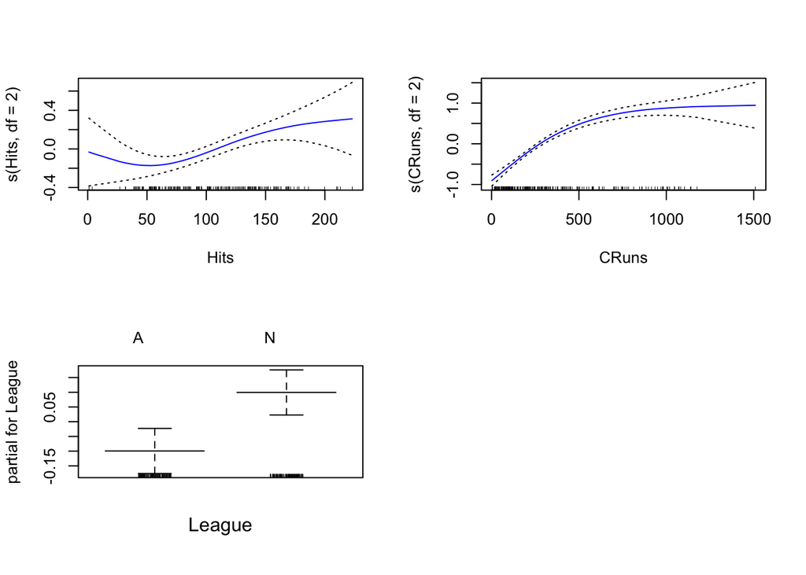

```r
hitters.gam <- gam(log(Salary) ~ s(Hits, df = 2) + s(CRuns, df = 2) + League, data = Hitters.train)

par(mfrow = c(2,2))
plot(hitters.gam, se = T, col = "blue")
summary(hitters.gam)
```

This model produced an AIC of 326.2644, which seems to be alright for a model of this size. All variables are significant for with Parametrix Effects.

##### c) Evaluate the model obtained on the test set. try different tuning parameters (if using s() then try different df’s; if using local regression lo(), try different span’s) and explain the results obtained.

```
##
## Call: gam(formula = log(Salary) ~ s(Hits, df = 4) + s(CRuns, df = 4) +
##     League, data = Hitters.test)
## Deviance Residuals:
##      Min       1Q   Median       3Q      Max
## -1.50460 -0.25034  0.01673  0.26679  1.14772
##
## (Dispersion Parameter for gaussian family taken to be 0.2528)
##
##     Null Deviance: 57.8336 on 62 degrees of freedom
## Residual Deviance: 13.3982 on 53.0001 degrees of freedom
## AIC: 103.2612
##
## Number of Local Scoring Iterations: NA
##
## Anova for Parametric Effects
##                  Df  Sum Sq Mean Sq F value    Pr(>F)
## s(Hits, df = 4)   1  6.1621  6.1621  24.376 8.281e-06 ***
## s(CRuns, df = 4)  1 14.1996 14.1996  56.170 7.219e-10 ***
## League            1  0.0725  0.0725   0.287    0.5944
## Residuals        53 13.3982  0.2528
## ---
## Signif. codes:  0 '***' 0.001 '**' 0.01 '*' 0.05 '.' 0.1 ' ' 1
##
## Anova for Nonparametric Effects
##                  Npar Df  Npar F     Pr(F)
## (Intercept)
## s(Hits, df = 4)        3  1.0452    0.3802
## s(CRuns, df = 4)       3 13.1168 1.601e-06 ***
## League
## ---
## Signif. codes:  0 '***' 0.001 '**' 0.01 '*' 0.05 '.' 0.1 ' ' 1
```

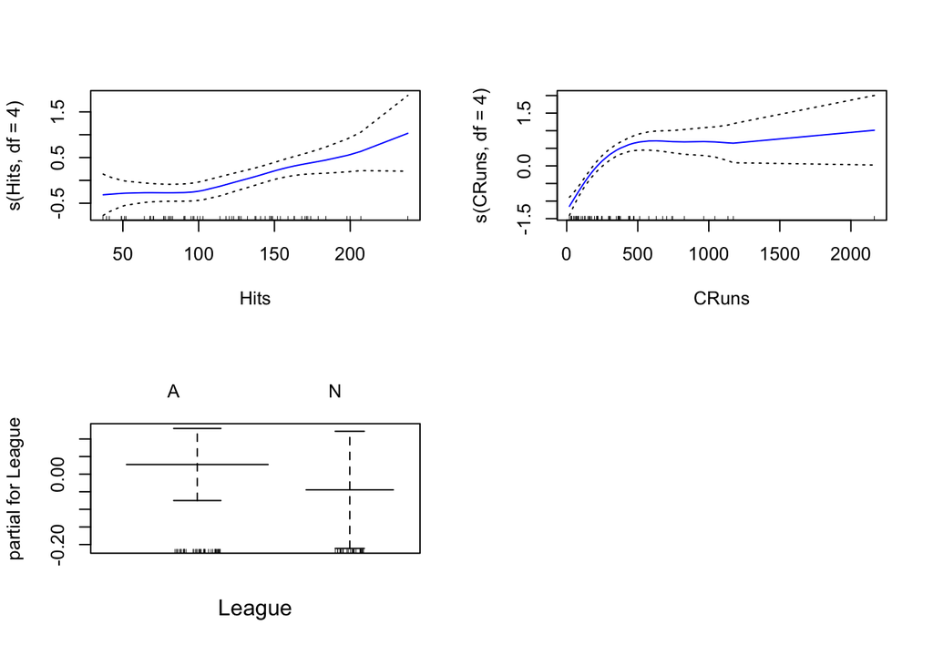

```r
hitters.gam.test <- gam(log(Salary) ~ s(Hits, df = 4) + s(CRuns, df = 4) + League, data = Hitters.test)

par(mfrow = c(2,2))
plot(hitters.gam.test, se = T, col = "blue")
summary(hitters.gam.test)
```

##### d) For which variables, if any, is there evidence of a non-linear relationship with the response?

It seems that there is a non-linear relationship with the CRuns and the response, shown from ANOVA for Nonparametric Effects.

# Question 2

### This question relates to the **Credit** data set. (Regression problem)

#### First, split the data set by running the following command lines:

```r
data("Credit")
set.seed(1234)
Credit <- Credit[,-1] # remove ID column
train.c <- sample(nrow(Credit), 300)
Credit.train <- Credit[train.c,]
Credit.test <- Credit[-train.c,]
```

##### a) Fit a tree to the training data, with **Balance** as the response and the other variables. Use the **summary()** function to produce summary statistics about the tree, and describe the results obtained. What is the training MSE? How many terminal nodes does the tree have?

```r
credit.tree <- tree(Balance ~ ., data = Credit.train)
summary(credit.tree)
```

```
##
## Regression tree:
## tree(formula = Balance ~ ., data = Credit.train)
## Variables actually used in tree construction:
## [1] "Rating"  "Income"  "Student" "Limit"
## Number of terminal nodes:  10
## Residual mean deviance:  27320 = 7923000 / 290
## Distribution of residuals:
##    Min. 1st Qu.  Median    Mean 3rd Qu.    Max.
## -419.90  -67.17  -38.31    0.00   92.56  549.60
```

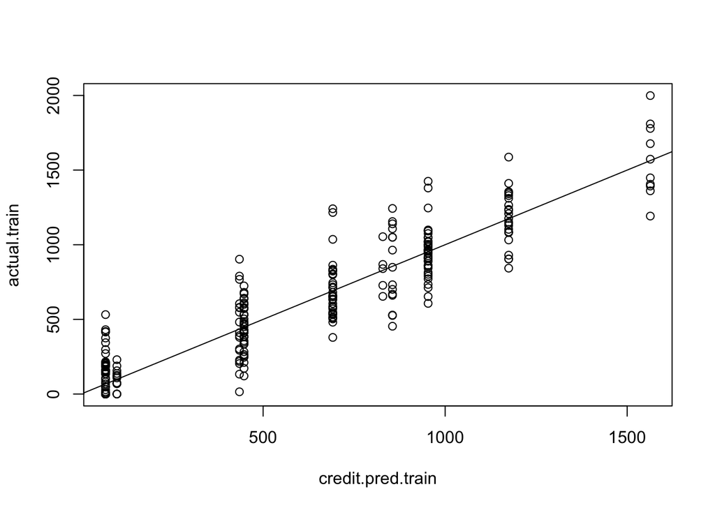

```r
# MSE

credit.pred.train <- predict(credit.tree, newdata = Credit.train)
actual.train <-Credit.train$Balance
plot(credit.pred.train, actual.train)
abline(0,1)
```

```r
round(mean((credit.pred.train-actual.train)^2))
```

```
## [1] 26410
```

For this tree model, the only variables used in construction are: “Rating”, “Income”, “Student”, “Limit”. There are 10 terminal nodes. I found the MSE to be 26410 for the training set.

##### b) Type in the name of the tree object to get a detailed text output. Pick one of the terminal nodes, and interpret the information displayed.

```r
credit.tree
```

```
## node), split, n, deviance, yval
##       * denotes terminal node
##
##  1) root 300 63110000  519.90
##    2) Rating < 354 160  8789000  191.00
##      4) Rating < 278.5 101  1398000   67.17 *
##      5) Rating > 278.5 59  3193000  402.90
##       10) Income < 44.639 46  1584000  489.00
##         20) Student: No 41   842900  447.50 *
##         21) Student: Yes 5    93090  828.80 *
##       11) Income > 44.639 13    62740   98.31 *
##    3) Rating > 354 140 17210000  895.90
##      6) Limit < 6769 91  6815000  755.80
##       12) Income < 60.2745 73  3509000  834.90
##         24) Limit < 5353 33  1203000  691.40 *
##         25) Limit > 5353 40  1066000  953.20 *
##       13) Income > 60.2745 18   996300  434.90 *
##      7) Limit > 6769 49  5286000 1156.00
##       14) Rating < 714 39  2645000 1052.00
##         28) Income < 100.151 24   745100 1175.00 *
##         29) Income > 100.151 15   959600  855.30 *
##       15) Rating > 714 10   555900 1564.00 *
```

Choosing node 12. This node asked whether or not the income was less than 60.2745. If income was in this threshold, then the tree split the average, and if you’re income was less than 60.2745, then the balance for this path would be 834.90.

##### c) Create a plot of the tree, and interpret the results.

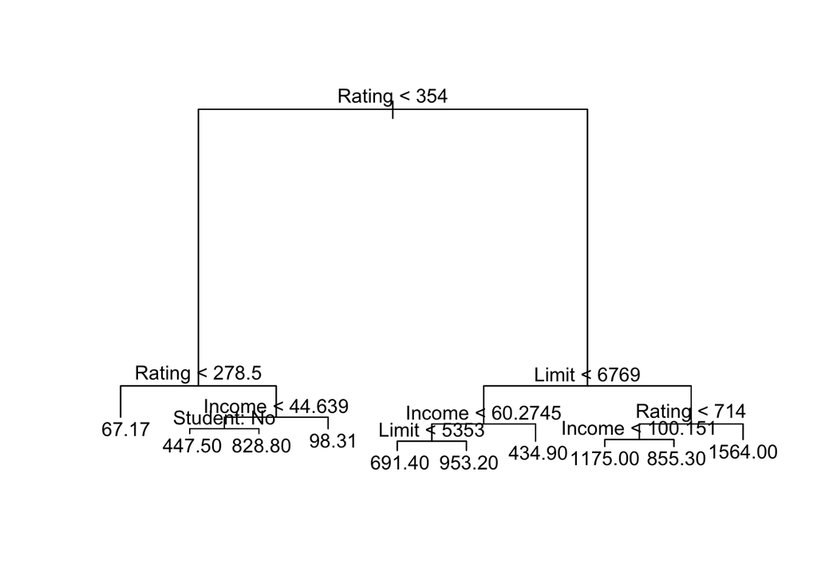

```r
plot(credit.tree)
text(credit.tree, pretty = 0)
```

We can see here from the plot that there are indeed 10 terminal nodes, with the most important ones being Rating, Limit, and Income.

##### d) Predict the response on the test data. What is the test MSE?

```r
credit.pred.test <- predict(credit.tree, newdata = Credit.test)
head(credit.pred.test)
```

```
##          1          3          5          8          9         11
##  447.51220  855.33333  691.36364 1174.54167   67.16832 1174.54167
```

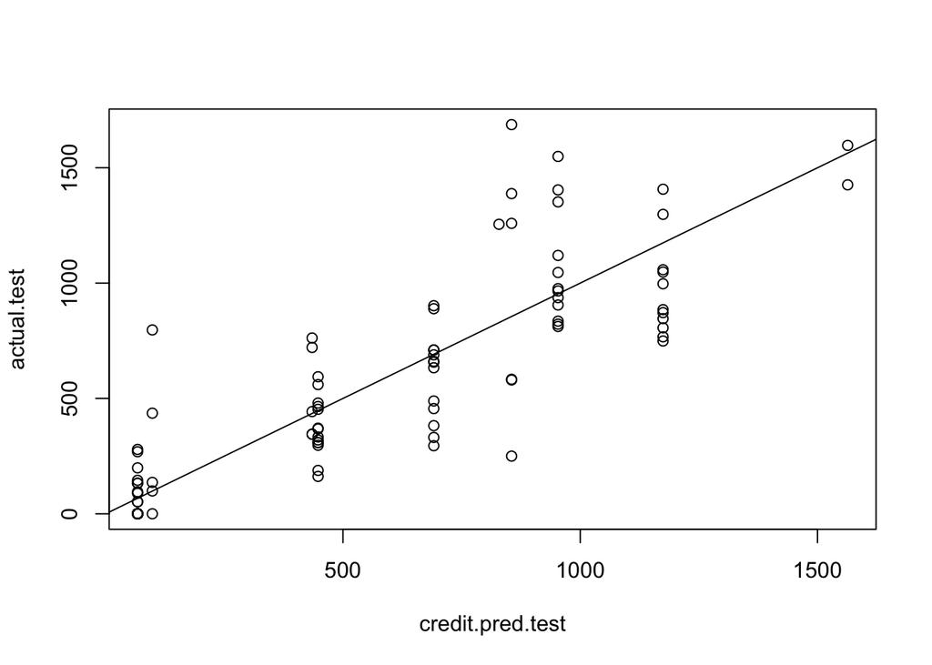

```r
actual.test <-Credit.test$Balance
plot(credit.pred.test, actual.test)
abline(0,1)
```

```r
round(mean((credit.pred.test-actual.test)^2))
```

```
## [1] 54493
```

Making predictions on the test set, the predictions look pretty scattered all over the place. I would think that this is due to the distribution of wealth not being equal across the globe. I found the MSE for the test set to be much much higher than training MSE, which is worrisome.

##### e) Apply the **cv.tree()** function to the training set in order to determine the optimal tree size.

```r
cv.credit <- cv.tree(credit.tree)
best.size <- cv.credit$size[which.min(cv.credit$dev)]
best.size
```

```
## [1] 10
```

The best size for the tree seems to be K = 10.

##### f) Produce a plot with tree size on the x-axis and cross-validated error on the y-axis.

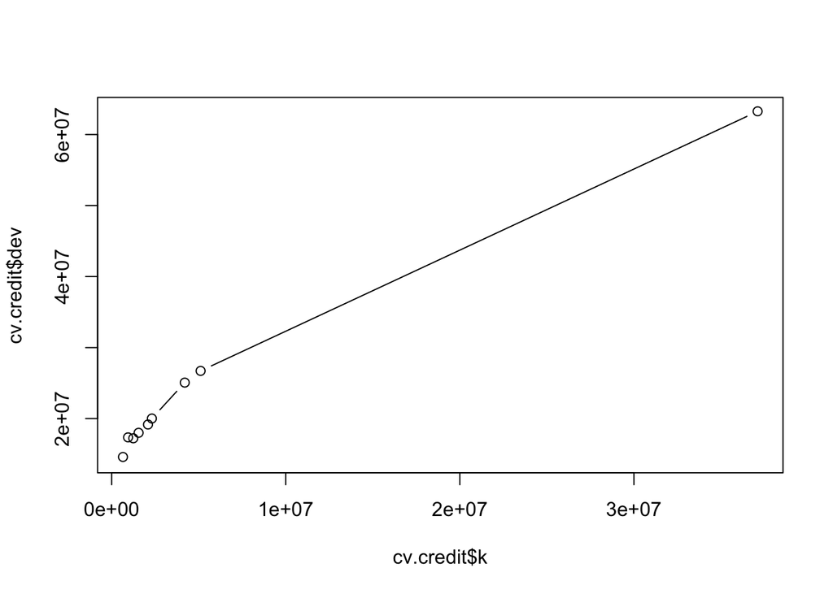

```r
plot(cv.credit$k, cv.credit$dev, type = "b") # main plot
```

##### g) Which tree size corresponds to the lowest cross-validated error?

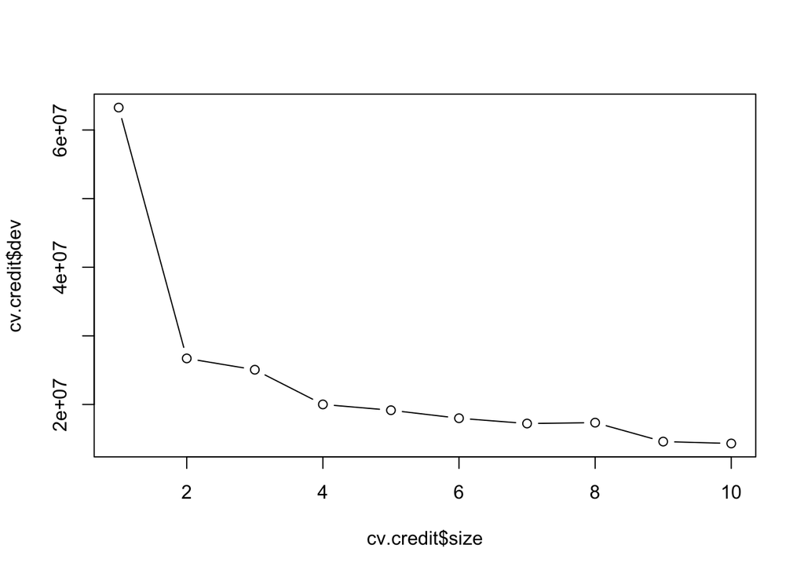

```r
plot(cv.credit$size, cv.credit$dev, type = "b")
```

Judging from the plot, it looks like the size of 10 is corresponds to the lowest error.

##### h) Produce a pruned tree corresponding to the optimal tree size obtained using cross-validation. If cross-validation does not lead to selection of a pruned tree, then create a pruned tree with five terminal nodes.

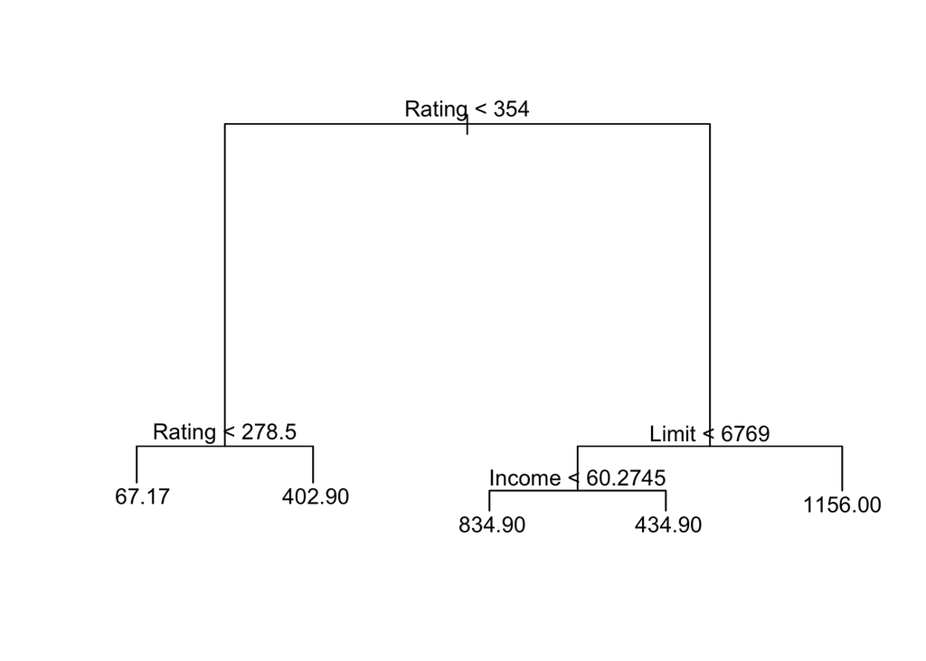

```r
#prune.credit <- prune.tree(credit.tree, best = best.size) #use prune.misclass for next part
#plot(prune.credit) # the plot is the same
#text(prune.credit, pretty = 0)
#prune.credit

prune.credit <- prune.tree(credit.tree, best = 5)
plot(prune.credit)
text(prune.credit, pretty = 0)
```

```r
prune.credit
```

```
## node), split, n, deviance, yval
##       * denotes terminal node
##
##  1) root 300 63110000  519.90
##    2) Rating < 354 160  8789000  191.00
##      4) Rating < 278.5 101  1398000   67.17 *
##      5) Rating > 278.5 59  3193000  402.90 *
##    3) Rating > 354 140 17210000  895.90
##      6) Limit < 6769 91  6815000  755.80
##       12) Income < 60.2745 73  3509000  834.90 *
##       13) Income > 60.2745 18   996300  434.90 *
##      7) Limit > 6769 49  5286000 1156.00 *
```

The plot is the same, so use a pruned tree with 5 terminal nodes.

##### i) Compare the training MSEs between the pruned and unpruned trees. Which is higher?

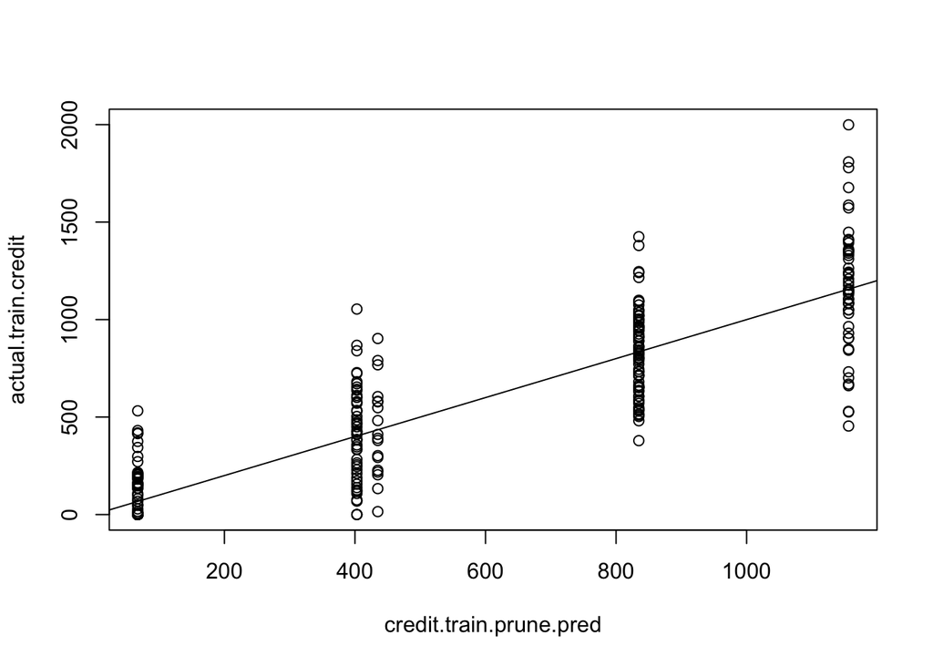

```r
# PRUNED TRAINING MSE
credit.train.prune.pred <- predict(prune.credit, newdata = Credit.train)
actual.train.credit <-Credit.train$Balance
plot(credit.train.prune.pred, actual.train.credit)
abline(0,1)
```

```r
(mean((credit.train.prune.pred-actual.train.credit)^2))
```

```
## [1] 47944.59
```

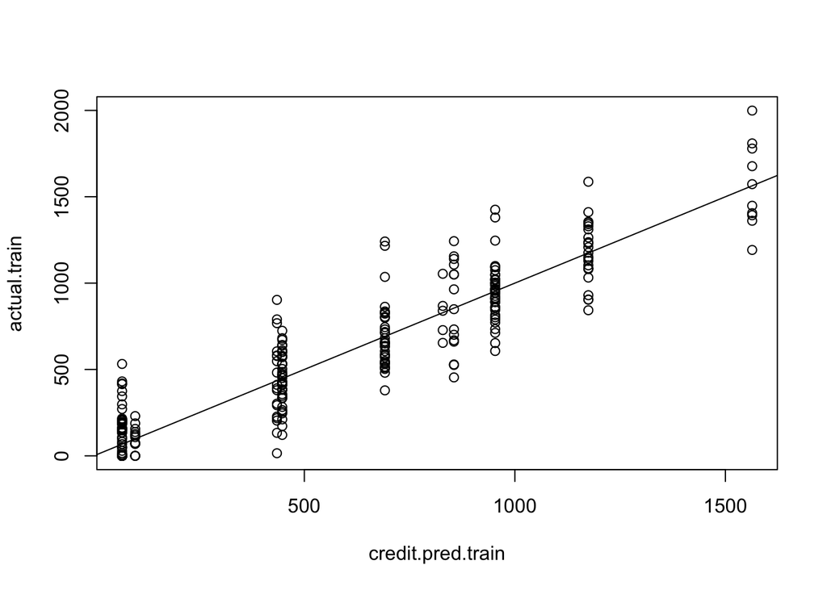

```r
# UNPRUNED TRAINING MSE

credit.pred.train <- predict(credit.tree, newdata = Credit.train)
plot(credit.pred.train, actual.train)
abline(0,1)
```

```r
(mean((credit.pred.train-actual.train)^2))
```

```
## [1] 26409.8
```

Comparatively, the training MSE for unpruned trees is a lot lower than the training MSE for pruned trees. Why is this? Is the pruned model poor?

##### j) Compare the test MSEs between the pruned and unpruned trees. Which is higher?

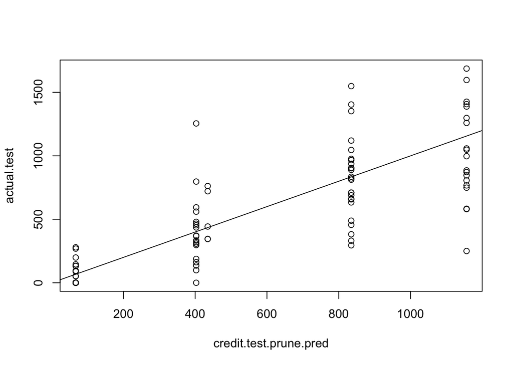

```r
# PRUNED TEST MSE
credit.test.prune.pred <- predict(prune.credit, newdata = Credit.test)
actual.test <-Credit.test$Balance
plot(credit.test.prune.pred, actual.test)
abline(0,1)
```

```r
(mean((credit.test.prune.pred-actual.test)^2))
```

```
## [1] 72198.94
```

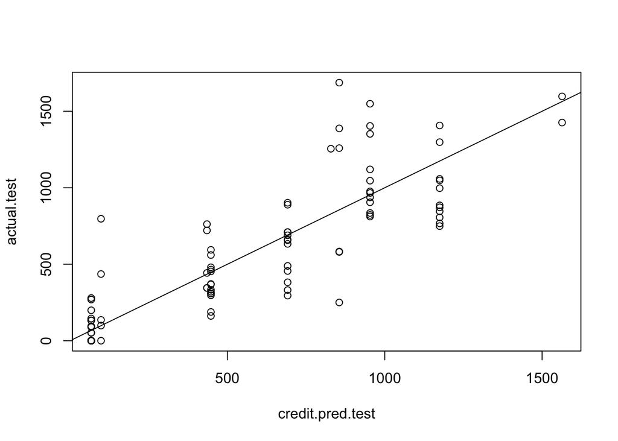

```r
# UNPRUNED TEST MSE

credit.pred.test <- predict(credit.tree, newdata = Credit.test)
plot(credit.pred.test, actual.test)
abline(0,1)
```

```r
(mean((credit.pred.test-actual.test)^2))
```

```
## [1] 54493.28
```

Again, the pruned test MSE is much higher than the unpruned test MSE.

##### k) Fit a bagging model to the training set with **Balance** as the response and the other variables. Use 1,000 trees **(ntree = 1000)**. Use the **importance()** function to determine which variables are most important.

```r
ncol(Credit.train) - 1 # number of predictors
```

```
## [1] 10
```

```r
bag.credit <- randomForest(Balance ~ ., data = Credit.train, mtry = 10, ntree = 1000, importance = T)
importance(bag.credit)
```

```
##              %IncMSE IncNodePurity
## Income    98.5998454    5138157.81
## Limit     51.3538311   27742422.16
## Rating    45.9294371   25627921.30
## Cards      0.9755303     196120.46
## Age        7.8811882     796145.29
## Education  4.0931546     295200.23
## Gender    -3.8625972      51875.26
## Student   67.9278815    2511423.46
## Married    1.4525244     103298.40
## Ethnicity  2.4087330     180770.62
```

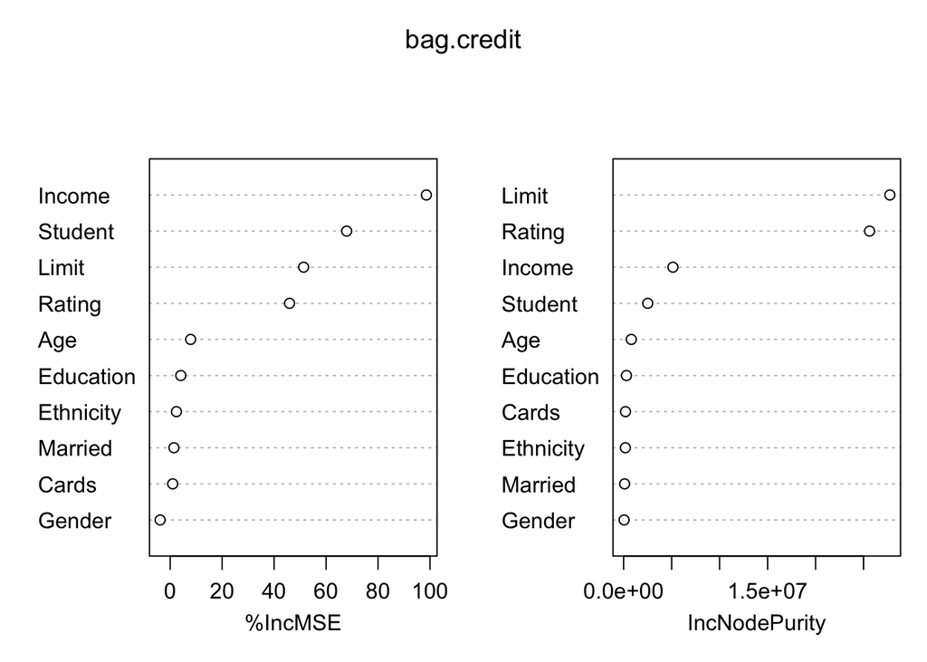

```r
varImpPlot(bag.credit)
```

mtry is set to 10 because I determined earlier in the chunk that the number of predictors should be 10. Using the importance function too, I have found the 10 predictors and their measure of importance.

##### l) Use the bagging model to predict the response on the test data. Compute the test MSE.

```r
bag.credit.pred <- predict(bag.credit, newdata = Credit.test)
head(bag.credit.pred) # predicting response
```

```
##         1         3         5         8         9        11
##  362.3289  832.6484  327.7744  924.0371  244.0596 1202.9326
```

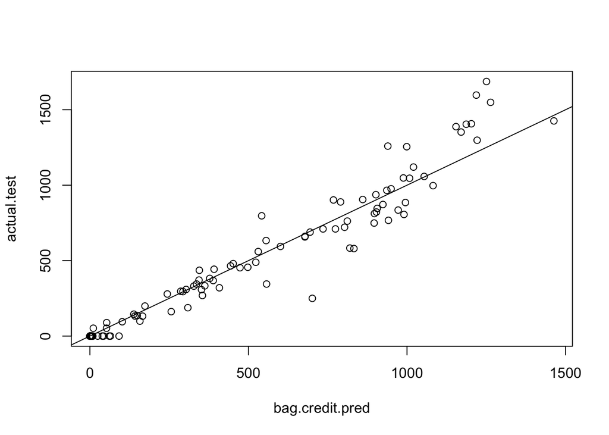

```r
actual.test <-Credit.test$Balance
plot(bag.credit.pred, actual.test)
abline(0,1)
```

```r
(mean((bag.credit.pred-actual.test)^2))
```

```
## [1] 15024.21
```

##### m) Fit a random forest model to the training set with **Balance** as the response and the other variables. Use 1,000 trees **(ntree = 1000)**. Use the **importance()** function to determine which variables are most important.

```r
sqrt(ncol(Credit.train) - 1)
```

```
## [1] 3.162278
```

```r
rf.credit <- randomForest(Balance ~ ., data = Credit.train, mtry = 3, importance = T, ntree = 1000)
rf.credit
```

```
##
## Call:
##  randomForest(formula = Balance ~ ., data = Credit.train, mtry = 3,      importance = T, ntree = 1000)
##                Type of random forest: regression
##                      Number of trees: 1000
## No. of variables tried at each split: 3
##
##           Mean of squared residuals: 22239.29
##                     % Var explained: 89.43
```

```r
importance(rf.credit)
```

```
##              %IncMSE IncNodePurity
## Income    40.4695663     7270185.6
## Limit     49.7083027    24955913.6
## Rating    44.8366090    22342692.2
## Cards      2.1487242      961089.2
## Age        3.2364938     2158534.1
## Education  0.4173546     1110805.1
## Gender    -0.3556838      215434.2
## Student   40.2746512     1986382.4
## Married    3.5371939      332790.2
## Ethnicity  1.2453850      537017.9
```

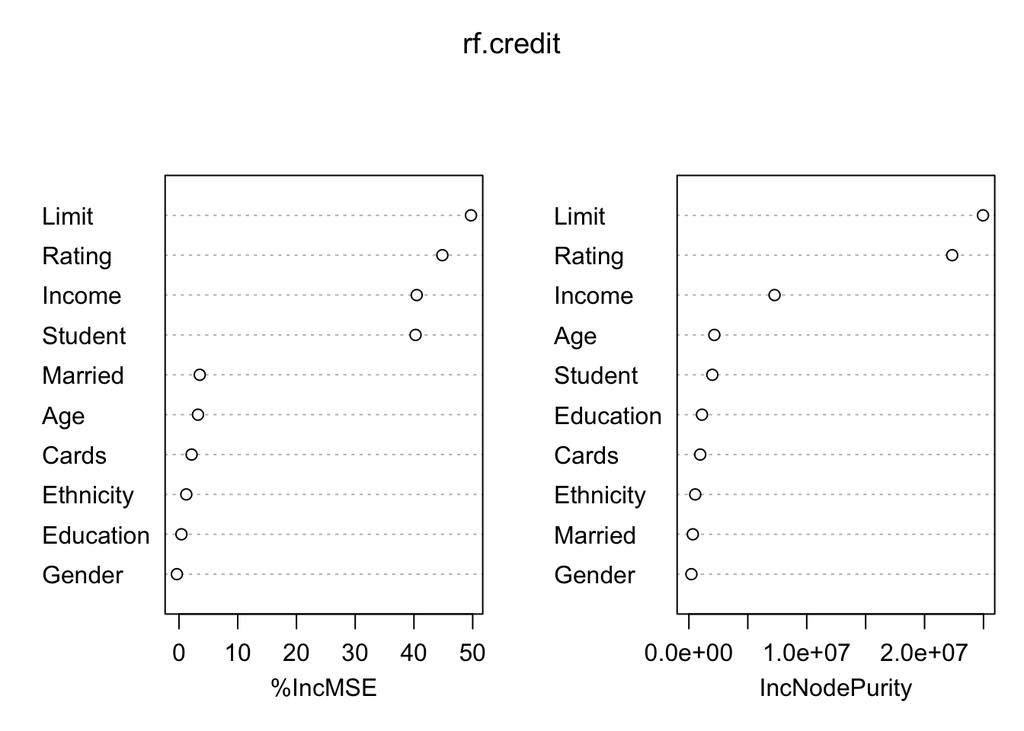

```r
varImpPlot(rf.credit)
```

The importance of each variable is shown. It looks like Cards, Age, Education, Gender, Married, and Ethnicity are almost useless in the importance factor.

##### n) Use the random forest to predict the response on the test data. Compute the MSE.

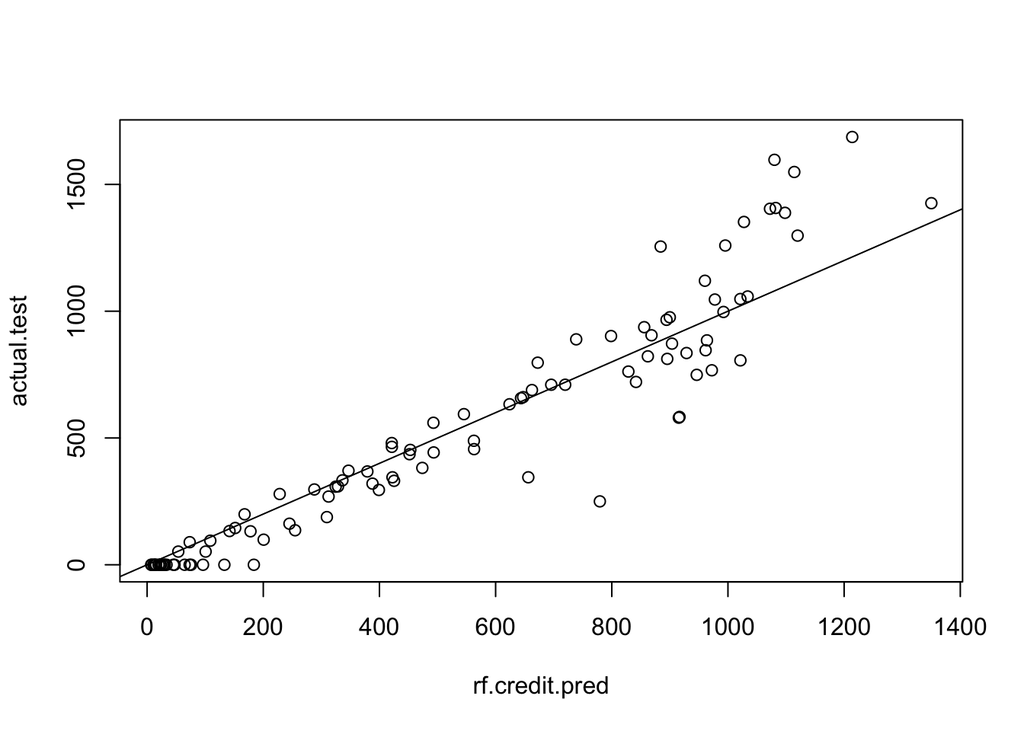

```r
rf.credit.pred <- predict(rf.credit, newdata = Credit.test)
actual.test <-Credit.test$Balance
plot(rf.credit.pred, actual.test)
abline(0,1)
```

```r
(mean((rf.credit.pred-actual.test)^2))
```

```
## [1] 24306.02
```

I calculated the test MSE to be 24306.02, which isn’t the best or the worst that we’ve seen so far.

##### o) Fit a boosting model to the training set with **Balance** as the response and the other variables. Use 1,000 trees, and a shrinkage value of 0.01 (lambda = 0.01). Which predictors appear to be the most important?

```r
credit.boost <- gbm(Balance ~., data = Credit.train, distribution = "gaussian", n.trees = 1000, shrinkage = 0.01)
credit.boost
```

```
## gbm(formula = Balance ~ ., distribution = "gaussian", data = Credit.train,
##     n.trees = 1000, shrinkage = 0.01)
## A gradient boosted model with gaussian loss function.
## 1000 iterations were performed.
## There were 10 predictors of which 8 had non-zero influence.
```

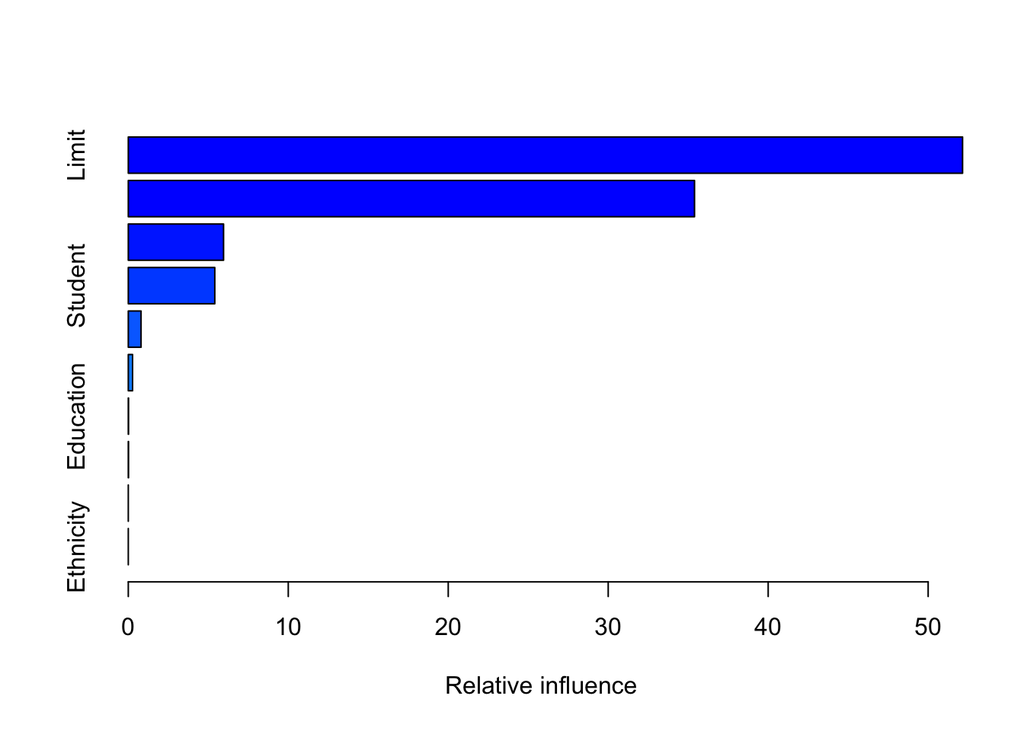

|  | var | rel.inf |
| --- | --- | --- |
| Limit | Limit | 52.15080126 |
| Rating | Rating | 35.39457042 |
| Income | Income | 5.95442974 |
| Student | Student | 5.40685682 |
| Age | Age | 0.79802739 |
| Cards | Cards | 0.26733156 |
| Education | Education | 0.01442402 |
| Married | Married | 0.01355879 |
| Gender | Gender | 0.00000000 |
| Ethnicity | Ethnicity | 0.00000000 |

```r
summary(credit.boost)
```

The boosted model states that there 10 predictors included, 8 of those had non-zero influence. The most influence was provided by Limit and Rating.

##### p) Use the boosting model to predict the response on the test data. Compute the test MSE.

```r
#First, we need to find the best number of trees.
credit.boost.cv <- gbm(Balance ~ ., data = Credit.train,
                      distribution = "gaussian", shrinkage = 0.01,
                      n.tree = 1000, cv.folds = 10)
which.min(credit.boost.cv$cv.error)
```

```
## [1] 1000
```

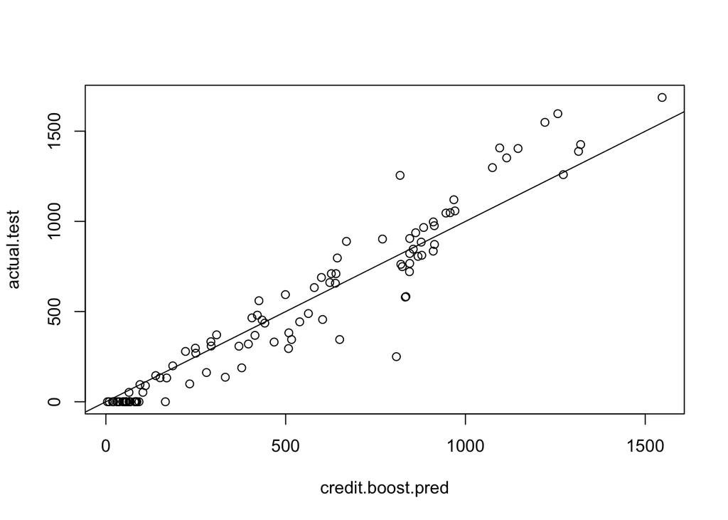

```r
# 1000 trees is the best number of trees to make predictions with.

credit.boost.pred <- predict(credit.boost, newdata = Credit.test, n.trees = which.min(credit.boost.cv$cv.error))
actual.test <-Credit.test$Balance
plot(credit.boost.pred, actual.test)
abline(0,1)
```

```r
(mean((credit.boost.pred-actual.test)^2))
```

```
## [1] 19036.85
```

After finding out the best number of trees was 1000 for the prediction, the test MSE for the boosting model was found to be 19036.85.

##### q) Fit a GAM to the training set with **Balance** as the response and the other variables, and use the GAM to predict the response on the test data. Compute the test MSE.

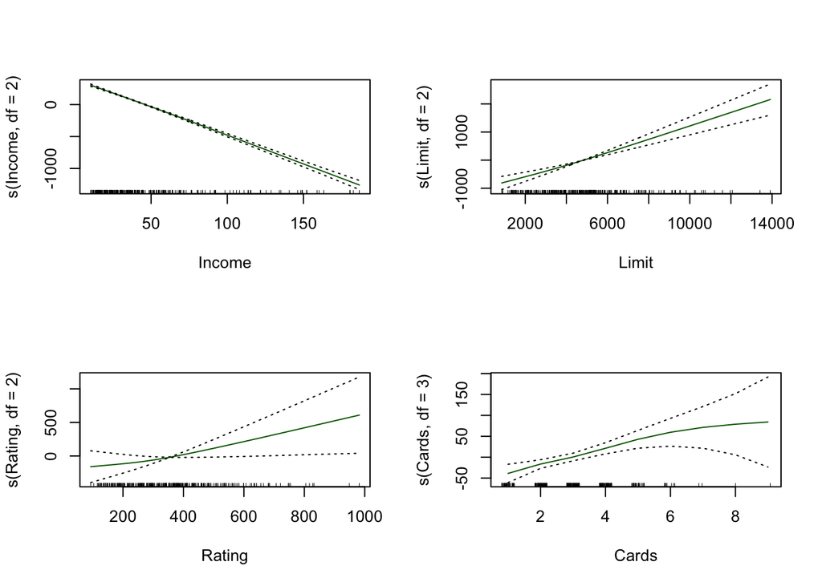

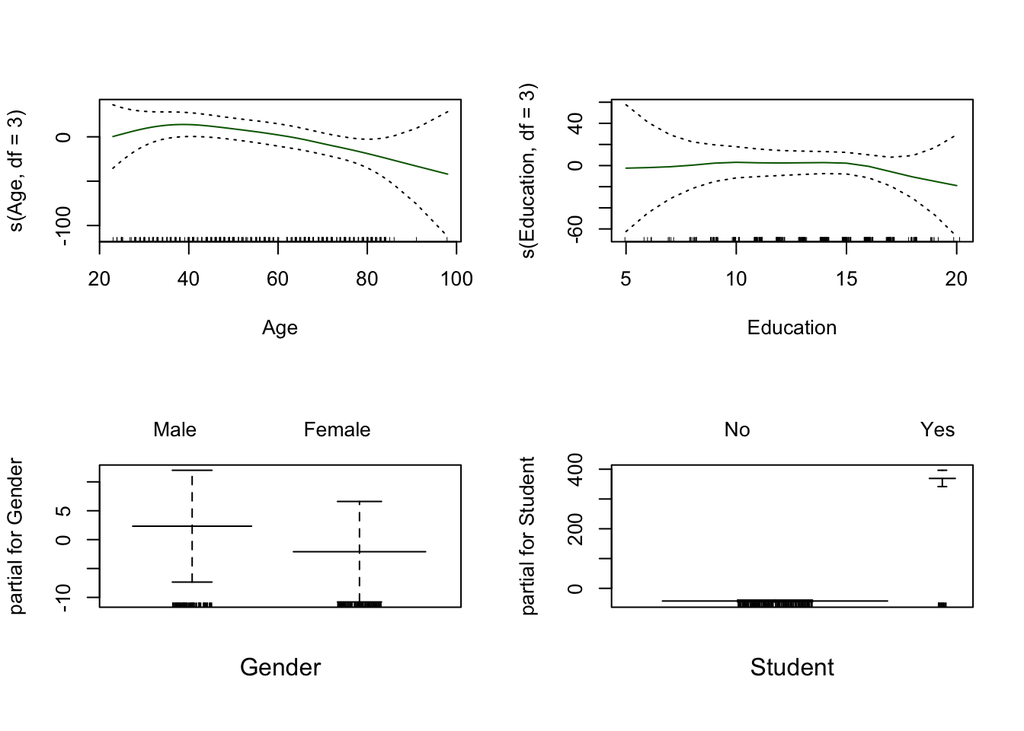

```r
credit.gam <- gam(Balance ~ s(Income, df = 2) + s(Limit, df = 2) + s(Rating, df = 2) + s(Cards, df = 3) + s(Age, df = 3) + s(Education, df = 3) + Gender + Student + Married + Ethnicity, data = Credit.train)

par(mfrow = c(2,2))
plot(credit.gam, se = T, col = "darkgreen")
```

```r
summary(credit.gam)
```

```
##
## Call: gam(formula = Balance ~ s(Income, df = 2) + s(Limit, df = 2) +
##     s(Rating, df = 2) + s(Cards, df = 3) + s(Age, df = 3) + s(Education,
##     df = 3) + Gender + Student + Married + Ethnicity, data = Credit.train)
## Deviance Residuals:
##      Min       1Q   Median       3Q      Max
## -212.070  -54.988   -4.021   38.925  233.941
##
## (Dispersion Parameter for gaussian family taken to be 6216.927)
##
##     Null Deviance: 63105022 on 299 degrees of freedom
## Residual Deviance: 1734521 on 278.9998 degrees of freedom
## AIC: 3494.101
##
## Number of Local Scoring Iterations: NA
##
## Anova for Parametric Effects
##                       Df   Sum Sq  Mean Sq   F value    Pr(>F)
## s(Income, df = 2)      1 12270404 12270404 1973.7089 < 2.2e-16 ***
## s(Limit, df = 2)       1 45598637 45598637 7334.5942 < 2.2e-16 ***
## s(Rating, df = 2)      1   208632   208632   33.5587 1.863e-08 ***
## s(Cards, df = 3)       1    43794    43794    7.0444 0.0084078 **
## s(Age, df = 3)         1    78595    78595   12.6421 0.0004429 ***
## s(Education, df = 3)   1    29318    29318    4.7158 0.0307300 *
## Gender                 1    34402    34402    5.5337 0.0193489 *
## Student                1  4574434  4574434  735.8031 < 2.2e-16 ***
## Married                1    10128    10128    1.6291 0.2028852
## Ethnicity              2    13640     6820    1.0970 0.3352967
## Residuals            279  1734521     6217
## ---
## Signif. codes:  0 '***' 0.001 '**' 0.01 '*' 0.05 '.' 0.1 ' ' 1
##
## Anova for Nonparametric Effects
##                      Npar Df Npar F     Pr(F)
## (Intercept)
## s(Income, df = 2)          1  2.311    0.1296
## s(Limit, df = 2)           1 68.157 5.995e-15 ***
## s(Rating, df = 2)          1 58.658 3.091e-13 ***
## s(Cards, df = 3)           2  0.625    0.5358
## s(Age, df = 3)             2  1.288    0.2776
## s(Education, df = 3)       2  0.696    0.4993
## Gender
## Student
## Married
## Ethnicity
## ---
## Signif. codes:  0 '***' 0.001 '**' 0.01 '*' 0.05 '.' 0.1 ' ' 1
```

```
## [1] 6708.778
```

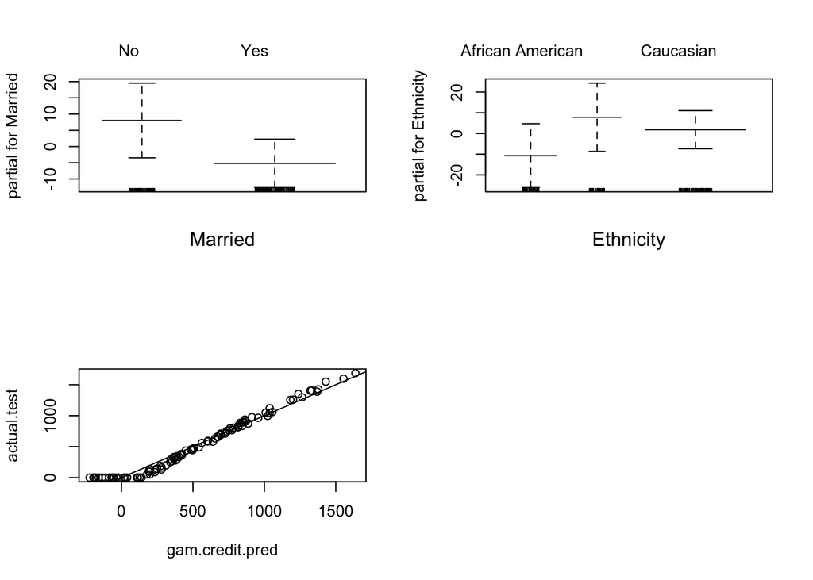

```r
# Compute test MSE
gam.credit.pred <- predict(credit.gam, newdata = Credit.test)
actual.test <-Credit.test$Balance
plot(gam.credit.pred, actual.test)
abline(0,1)
(mean((gam.credit.pred-actual.test)^2))
```

The Test MSE for the GAM model was calculated to be 6708.778, which is very low.

##### r) Compare the test MSEs between the unpruned trees, pruned trees, bagging, random forest, boosting, and GAM. Which performs the best?

```r
print(c("unpruned tree mse: ",(mean((credit.pred.test-actual.test)^2)))) # unpruned tree
```

```
## [1] "unpruned tree mse: " "54493.2755026102"
```

```r
print(c("pruned tree mse: ",(mean((credit.test.prune.pred-actual.test)^2)))) # pruned tree
```

```
## [1] "pruned tree mse: " "72198.9361444461"
```

```r
print(c("bagging mse: ",(mean((bag.credit.pred-actual.test)^2)))) # bagging
```

```
## [1] "bagging mse: "    "15024.2134195537"
```

```r
print(c("random forest mse: ",(mean((rf.credit.pred-actual.test)^2)))) # random forest
```

```
## [1] "random forest mse: " "24306.0216776133"
```

```r
print(c("boosting mse: ",(mean((credit.boost.pred-actual.test)^2)))) # boosting
```

```
## [1] "boosting mse: "   "19036.8532693583"
```

```r
print(c("gam mse: ",(mean((gam.credit.pred-actual.test)^2)))) # gam
```

```
## [1] "gam mse: "        "6708.77813477811"
```

It looks like the GAM performs the best. This could be because the modifications it makes to the variables included in the model.

# Question 3

### This question relates to the OJ data set. (Classification problem.)

#### First, we split the data set by using the following command lines:

```r
data("OJ")
set.seed(200)
train.o <- sample(nrow(OJ), 800)
OJ.train <- OJ[train.o,]
OJ.test <- OJ[-train.o,]
```

##### a) Fit a tree to the training data, with **Purchase** as the reponse and the other variables. Use the **summary()** function to produce summary statistics about the tree, and describe the results obtained. What is the training error rate? How many terminal nodes does the tree have?

```r
OJ.tree <- tree(Purchase ~ ., data = OJ.train)
summary(OJ.tree)
```

```
##
## Classification tree:
## tree(formula = Purchase ~ ., data = OJ.train)
## Variables actually used in tree construction:
## [1] "LoyalCH"       "ListPriceDiff" "PctDiscMM"
## Number of terminal nodes:  6
## Residual mean deviance:  0.7964 = 632.4 / 794
## Misclassification error rate: 0.1713 = 137 / 800
```

The training error rate observed here is 17%.

##### b) Type in the name of the tree object in order to get a detailed text output. Pick one of the terminal nodes, and interpret the information displayed.

```r
OJ.tree
```

```
## node), split, n, deviance, yval, (yprob)
##       * denotes terminal node
##
##  1) root 800 1075.000 CH ( 0.60250 0.39750 )
##    2) LoyalCH < 0.445519 279  285.200 MM ( 0.20789 0.79211 )
##      4) LoyalCH < 0.0356415 55    9.996 MM ( 0.01818 0.98182 ) *
##      5) LoyalCH > 0.0356415 224  254.100 MM ( 0.25446 0.74554 ) *
##    3) LoyalCH > 0.445519 521  500.800 CH ( 0.81382 0.18618 )
##      6) LoyalCH < 0.764572 269  338.600 CH ( 0.67658 0.32342 )
##       12) ListPriceDiff < 0.235 110  151.900 MM ( 0.46364 0.53636 )
##         24) PctDiscMM < 0.196196 86  118.100 CH ( 0.55814 0.44186 ) *
##         25) PctDiscMM > 0.196196 24   18.080 MM ( 0.12500 0.87500 ) *
##       13) ListPriceDiff > 0.235 159  148.000 CH ( 0.82390 0.17610 ) *
##      7) LoyalCH > 0.764572 252   84.130 CH ( 0.96032 0.03968 ) *
```

I am choosing node 4. The split criterion here is LoyalCH < 0.035, the number of observations in the branch is 55 with a deviance of 9.996 and an overall prediction for the branch of MM. Less than 2% of the observations in that branch take the value of CH, and the remaining 98% take the value of MM.

##### c) Create a plot of the tree, interpret the results.

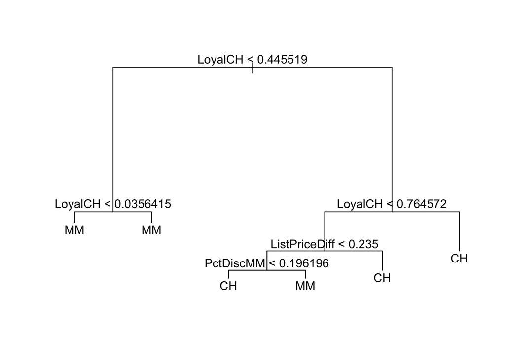

```r
plot(OJ.tree)
text(OJ.tree, pretty = 0)
```

The main branch is LoyalCH, and if you met the threshold or didn’t, the tree split up into the two sub-LoyalCH paths, one where it has many terminal nodes, meaning more outcomes, and one that has few terminal nodes, meaning if you follow this path then you are easily classified.

##### d) Predict the response on the test data, and produce a confusion matrix comparing the test labels to the predicted test labels. What is the test error rate?

```r
OJ.test.pred <- predict(OJ.tree, OJ.test, type = "class")
table(OJ.test.pred, OJ.test$Purchase)
```

```
##
## OJ.test.pred  CH  MM
##           CH 147  24
##           MM  24  75
```

```r
mean(OJ.test.pred != OJ.test$Purchase)
```

```
## [1] 0.1777778
```

The test error rate here is found to 17%.

##### e) Apply the **cv.tree()** function to the training set in order to determine the optimal tree size.

```r
cv.oj <- cv.tree(OJ.tree, FUN = prune.misclass)
names(cv.oj)
```

```
## [1] "size"   "dev"    "k"      "method"
```

```r
cv.oj
```

```
## $size
## [1] 6 5 2 1
##
## $dev
## [1] 165 165 168 318
##
## $k
## [1] -Inf    0    6  163
##
## $method
## [1] "misclass"
##
## attr(,"class")
## [1] "prune"         "tree.sequence"
```